# Projekt3

Szymon Popkiewicz, Kacper Prorok, Jan Pryl

2024-01-19

```r
library(tidyverse)
library(moments)
library(MASS)
set.seed(123)
```

## Jak zmienia się dokładność oszacowania w zależności od liczby danych

W naszym projekcie używamy dwóch funkcji, które posłużą nam do szacowania parametrów rozkładu Weibulla.

- Pierwsza funkcja

```r
Badanie <- function(l, sh,sc) {
  dane <- rweibull(l, shape=sh, scale=sc)
  optim(c(sh,sc), funkcja_w, dane = dane,lower = c(0.000000000000000000001 , 0.000000000000000001), method = "L-BFGS-B" )
}
```

- Druga funkcja

```r
Badanie1<-function(l,sh,sc){
  data <- rweibull(l, shape = sh, scale = sc)
fit <- fitdistr(data, densfun = "weibull", start = list(shape = 1, scale =1))
  return(fit$estimate)
}
```

Używamy dwóch funkcji, ponieważ dla niektórych parametrów R nie radził sobie z pierwszą funkcją.

Natomiast tutaj mamy funkcję liczącą sumę logarytmów prawdopodobieństw:

```r
funkcja_w <- function(dane,parametry) {
  -sum(log(dweibull(dane, shape = parametry[1], scale = parametry[2])))
}
```

Poniższy schemat pokazuje generowanie danych dla shape=0.5 scale=1:

```r
wyniki_1_1 <- data.frame()

 for (i in 1:300) {
 wyniki_1_1 <- rbind(wyniki_1_1,c(Badanie1(50,0.5,1),Badanie1(100,0.5,1),Badanie1(200,0.5,1),Badanie1(500,0.5,1),Badanie1(1000,0.5,1),Badanie1(5000,0.5,1),Badanie1(10000,0.5,1)))
 }
colnames(wyniki_1_1)<-c("sh50","sc50","sh100","sc100","sh200","sc200","sh500","sc500","sh1000","sc1000",
                         "sh5000","sc5000","sh10000","sc10000")

summary_1_1<-rbind(colMeans(wyniki_1_1),sapply(wyniki_1_1, sd),sapply(wyniki_1_1, skewness),sapply(wyniki_1_1, kurtosis))
summary_1_1<-as.data.frame(summary_1_1)
rownames(summary_1_1)<-c("srednia","odchylenie", "skosnosc","kurtoza")
summary_1_1<-t(summary_1_1)

datash_1_1<-as.data.frame(summary_1_1[seq(1,14,by=2),])
datasc_1_1<-as.data.frame(summary_1_1[seq(2,14,by=2),])


wilkSH_1_1<-data.frame()
wilkSC_1_1<-data.frame()

for(i in seq(1,14,by=2)){
wilkSH_1_1<-rbind(wilkSH_1_1,shapiro.test(wyniki_1_1[,i])$p.value)
}

for(i in seq(2,14,by=2)){
wilkSC_1_1<-rbind(wilkSC_1_1,shapiro.test(wyniki_1_1[,i])$p.value)
}
```

Poniżej przedstawiamy schemat generowania danych. Przykład dla scale=10 shape=4:

```r
wyniki_4_10 <- data.frame()

for (i in 1:300) {
  wyniki_4_10 <- rbind(wyniki_4_10, c(Badanie(50,4,10)$par,Badanie(100,4,10)$par,
                                     Badanie(200,4,10)$par,Badanie(500,4,10)$par,
                                     Badanie(1000,4,10)$par,Badanie(5000,4,10)$par,
                                     Badanie(10000,4,10)$par))
}
colnames(wyniki_4_10)<-c("sh50","sc50","sh100","sc100","sh200","sc200","sh500","sc500","sh1000","sc1000",
                         "sh5000","sc5000","sh10000","sc10000")

summary_4_10<-rbind(colMeans(wyniki_4_10),sapply(wyniki_4_10, sd),sapply(wyniki_4_10, skewness),sapply(wyniki_4_10, kurtosis))
summary_4_10<-as.data.frame(summary_4_10)
rownames(summary_4_10)<-c("srednia","odchylenie", "skosnosc","kurtoza")
summary_4_10<-t(summary_4_10)

datash_4_10<-as.data.frame(summary_4_10[seq(1,14,by=2),])
datasc_4_10<-as.data.frame(summary_4_10[seq(2,14,by=2),])



wilkSH_4_10<-data.frame()
wilkSC_4_10<-data.frame()

for(i in seq(1,14,by=2)){
wilkSH_4_10<-rbind(wilkSH_4_10,shapiro.test(wyniki_4_10[,i])$p.value)
}

for(i in seq(2,14,by=2)){
wilkSC_4_10<-rbind(wilkSC_4_10,shapiro.test(wyniki_4_10[,i])$p.value)
}
```

## Zapoznianie z rozkładem oszacowań przy różnych licznościach

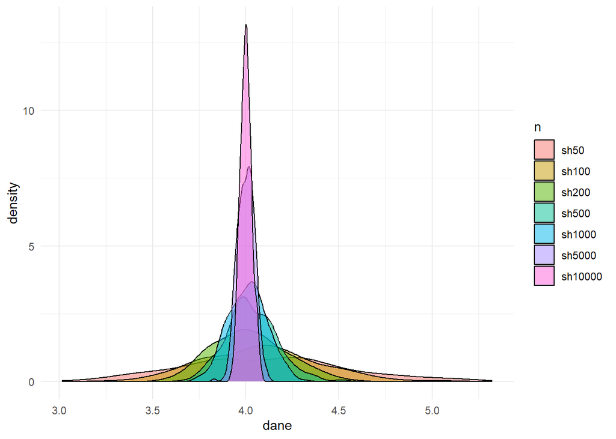

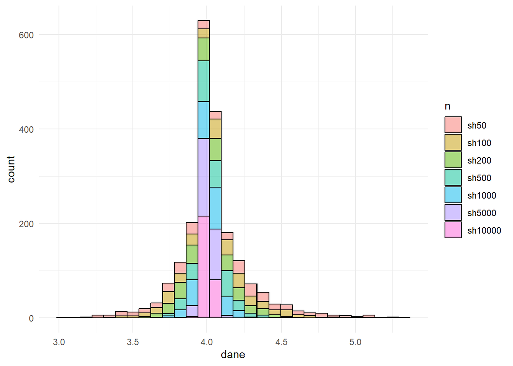

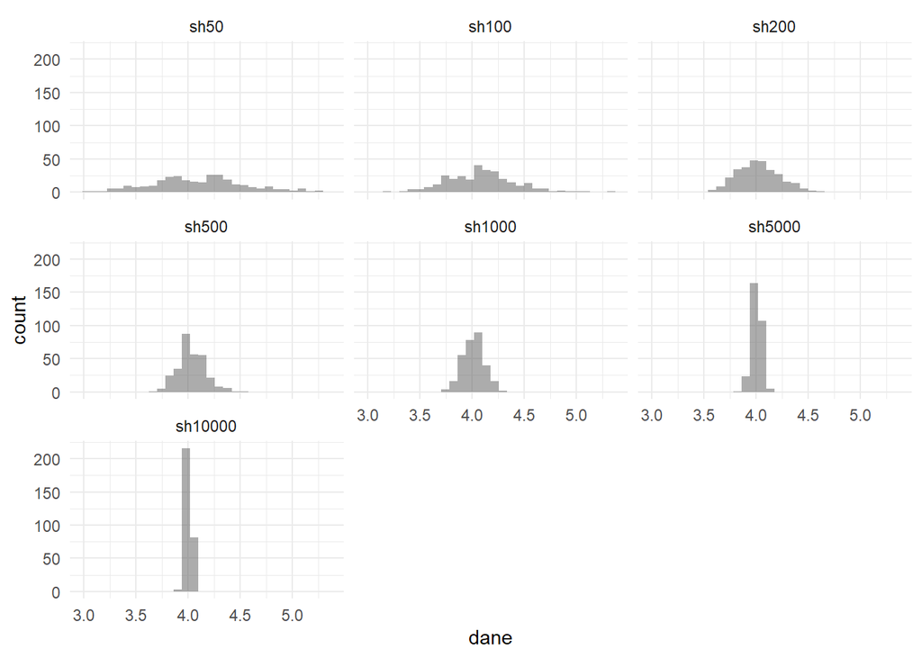

```r
datash_4_10
```

```
##          srednia odchylenie   skosnosc  kurtoza
## sh50    4.101899 0.43772844  0.1999038 2.787786
## sh100   4.083329 0.31893439  0.3669416 3.614260
## sh200   4.020271 0.19913152  0.2711635 2.690792
## sh500   4.031288 0.13773562  0.3669355 3.554590
## sh1000  4.010557 0.10446153  0.0441422 2.772991
## sh5000  4.000552 0.04512321 -0.1437143 2.998180
## sh10000 4.000590 0.03021071  0.1583946 2.795540
```

W przypadku oszacowanego parametru shape dla rozkładu Weibulla o parametrach scale=10,shape=4 widzimy, że średnia zbiega się do oczekiwanej czwórki. Odchylenie standardowe wyraźnie maleje wraz ze wzrostem ilości danych.

```r
datasc_4_10
```

```
##           srednia odchylenie    skosnosc  kurtoza
## sc50    10.026099 0.37035205  0.09564626 3.611403
## sc100    9.979106 0.26769882  0.07359434 3.002792
## sc200    9.987862 0.17517931 -0.22601617 3.367440
## sc500   10.004104 0.11455007  0.10758137 2.643297
## sc1000   9.998806 0.08901768  0.08815721 3.225728
## sc5000  10.001296 0.03702965 -0.20033471 2.706421
## sc10000  9.999906 0.02605638  0.10374850 2.847099
```

Średnia oszacowanego parametru `scale` z rozkładu Weibulla o parametrach scale=10,shape=4 nie wykazuje większych zmian podczas zmieniania ilości danych. Odchylenie standardowe natomiast maleje.

Skośność we wszystkich przypadkach jest bliska 0, co oznacza że rozkład szacowanego parametru jest raczej symetryczny niezależnie od ilości danych. Kurtoza ponownie zmienia się niemonotonicznie, ale cały czas jest bliska wartości 3.

*Do oszacowania parametrów shape=0.5 oraz scale=1 użyliśmy naszej drugiej funkcji.*

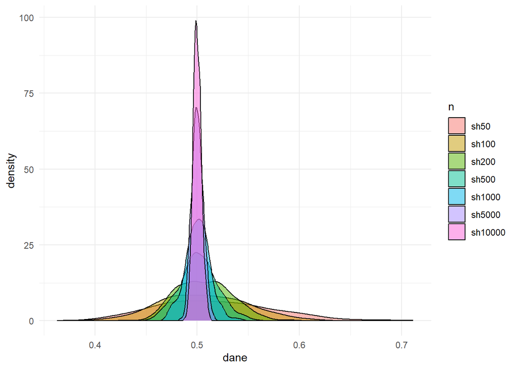

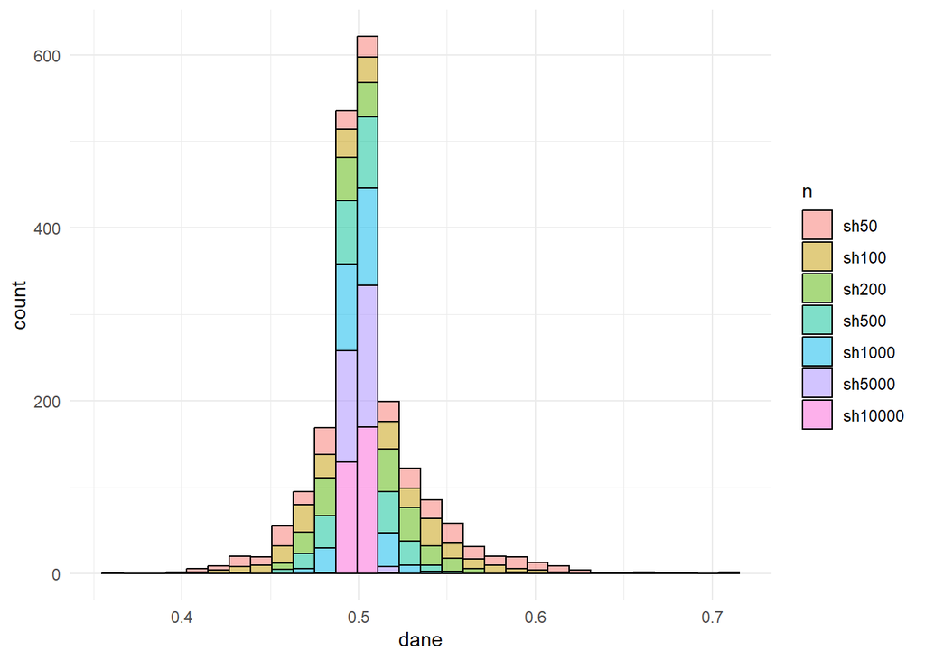

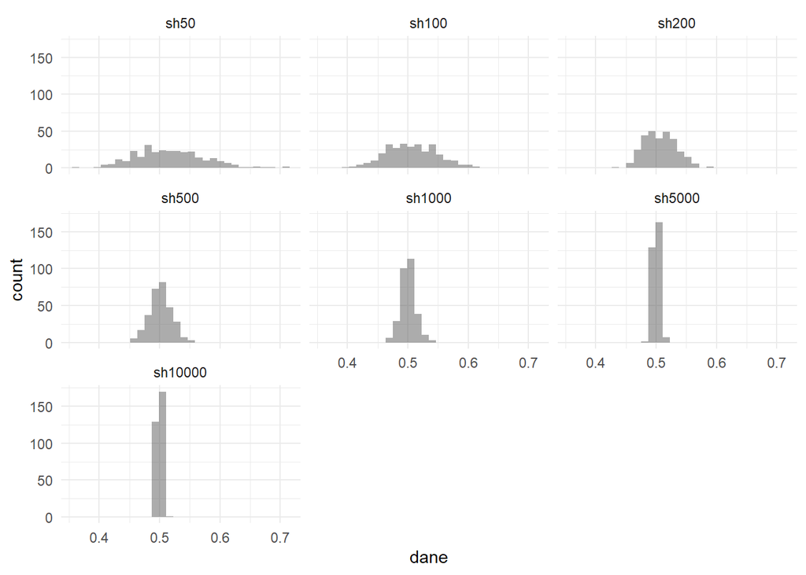

```r
datash_1_1
```

```
##           srednia  odchylenie  skosnosc  kurtoza
## sh50    0.5169729 0.057671762 0.4493032 3.297218
## sh100   0.5061717 0.041807737 0.1177098 2.671352
## sh200   0.5069829 0.026365496 0.2501539 2.816839
## sh500   0.5015896 0.018325280 0.1255872 3.013297
## sh1000  0.5005880 0.012029118 0.1423731 3.480482
## sh5000  0.5002337 0.005495941 0.1577248 2.849912
## sh10000 0.4999919 0.003917826 0.1901125 3.036090
```

```r
datasc_1_1
```

```
##           srednia odchylenie    skosnosc  kurtoza
## sc50    1.0221141 0.30206350  0.66629347 3.567282
## sc100   1.0054632 0.22565649  0.42045986 3.482675
## sc200   1.0232950 0.15181358  0.23505116 2.885947
## sc500   1.0045946 0.09236872  0.16276798 2.945247
## sc1000  0.9989050 0.06542647  0.21263055 2.923122
## sc5000  0.9987945 0.03090827 -0.04682885 2.797140
## sc10000 1.0011154 0.01960532  0.12835814 2.941023
```

Dla parametru `scale` analogiczna sytuacja jak dla przypadku `shape`.

## Sprawdzanie czy oszacowania parametrów są zgodne z rozkładem normalnym

**H0:dane są zgodne z rozkładem normalnym**

**H1:dane nie są zgodne z rozkładem normalnym**

Dla danych z rozkladu weibulla o parametrach `scale`=10 oraz `shape`=4 wartości p-value w teście shapiro-wilka wyglądają następująco:

```r
wilkSC_4_10
```

```
##   X0.0868008320226762
## 1          0.08680083
## 2          0.44057767
## 3          0.29181063
## 4          0.60927816
## 5          0.82877041
## 6          0.08392249
## 7          0.53148788
```

Wszystkie rozkłady oszacowań parametrów `scale` jest zgodna z rozkładem normalnym. Można więc powiedzieć, że rozkład jest przeważnie zgodny z rozkładem normalnym.

```r
wilkSH_4_10
```

```
##   X0.150212390031132
## 1         0.15021239
## 2         0.03970261
## 3         0.09906374
## 4         0.03035281
## 5         0.91883427
## 6         0.29562917
## 7         0.33032570
```

Natomiast dla rozkładów oszacowań parametrów `shape` większość z nich jest zgodna z rozkładem normalnych. Można założyć, że przy dużej ilości danych (>1000) rozkład jest zgodny z normalnym.

### Dla rozkładu scale=1 shape=0.5

```r
wilkSC_1_1
```

```
##   X9.24717549137195e.06
## 1          9.247175e-06
## 2          4.168303e-03
## 3          4.647454e-01
## 4          7.285824e-01
## 5          4.340017e-01
## 6          6.269095e-01
## 7          6.092515e-01
```

Dla liczby danych równych 200 i powyżej, rozkład oszacowań parametru scale jest zgodny z rozkładem normalnym.

```r
wilkSH_1_1
```

```
##   X0.00716602956249129
## 1           0.00716603
## 2           0.61687311
## 3           0.05664585
## 4           0.71569937
## 5           0.10513038
## 6           0.74644034
## 7           0.58734197
```

## Szacowanie parametru scale

Tworzymy funkcję `Badanie2`, która umożliwi nam szacowanie paramatetru scale, a nie dwóch naraz.

```r
funkcja_w2 <- function(dane, shape, scale) {
  -sum(log(dweibull(dane, shape = shape, scale = scale)))
}
Badanie2 <- function(l, sh,sc) {
  dane <- rweibull(l, shape=sh, scale=sc)
  optim(sc, funkcja_w2, dane = dane,shape = sh, lower = c(0.0000001 , 0.0001), method = "L-BFGS-B" )
}
```

```r
wyniki_scale_4_10 <- data.frame()
for (i in 1:300) {
wyniki_scale_4_10 <- rbind(wyniki_scale_4_10, c(Badanie2(50,4,10)$par,Badanie2(100,4,10)$par,
                                     Badanie2(200,4,10)$par,Badanie2(500,4,10)$par,
                                     Badanie2(1000,4,10)$par,Badanie2(5000,4,10)$par,
                                     Badanie2(10000,4,10)$par))
}

colnames(wyniki_scale_4_10)<-c("sc50","sc100","sc200","sc500","sc1000","sc5000","sc10000")

summary_wyniki_scale_4_10<-rbind(colMeans(wyniki_scale_4_10),sapply(wyniki_scale_4_10, sd),sapply(wyniki_scale_4_10, skewness),sapply(wyniki_scale_4_10, kurtosis))
summary_wyniki_scale_4_10<-as.data.frame(summary_wyniki_scale_4_10)
rownames(summary_wyniki_scale_4_10)<-c("srednia","odchylenie", "skosnosc","kurtoza")
summary_wyniki_scale_4_10<-t(summary_wyniki_scale_4_10)
```

Przedstawiamy wyniki dla oszacowań jednego parametru scale:

```r
summary_wyniki_scale_4_10
```

```
##          srednia odchylenie    skosnosc  kurtoza
## sc50    9.990791 0.33242281 -0.01794873 3.163342
## sc100   9.990509 0.27768372 -0.01779372 3.545028
## sc200   9.991560 0.17360471  0.04545066 2.630104
## sc500   9.996121 0.11608559 -0.05880733 2.968571
## sc1000  9.993068 0.07843828 -0.01513419 2.847964
## sc5000  9.998509 0.03407861 -0.08238251 2.838665
## sc10000 9.998597 0.02614971  0.04818160 2.565212
```

Dla porówniania wyniki szacowanego parametru scale przy estymacji obu parametrów:

```r
datasc_4_10
```

```
##           srednia odchylenie    skosnosc  kurtoza
## sc50    10.026099 0.37035205  0.09564626 3.611403
## sc100    9.979106 0.26769882  0.07359434 3.002792
## sc200    9.987862 0.17517931 -0.22601617 3.367440
## sc500   10.004104 0.11455007  0.10758137 2.643297
## sc1000   9.998806 0.08901768  0.08815721 3.225728
## sc5000  10.001296 0.03702965 -0.20033471 2.706421
## sc10000  9.999906 0.02605638  0.10374850 2.847099
```

**Zauważamy lekką zależność między średnią szacowanego parametru, a ilością danych w wariancie gdy szacujemy jeden parametr. Reszta statystyk jest bardzo podobna do wariantu z szacowaniem dwóch parametrów naraz.**

## Szacowanie parametru shape

```r
Badanie3 <- function(l, sh,sc) {
  dane <- rweibull(l, shape=sh, scale=sc)
  optim(sh, funkcja_w2, dane = dane,scale = sc, lower = c(0.0000001 , 0.0001), method = "L-BFGS-B" )
}
```

```r
wyniki_shape_4_10 <- data.frame()
for (i in 1:300) {
wyniki_shape_4_10 <- rbind(wyniki_shape_4_10, c(Badanie3(50,4,10)$par,Badanie3(100,4,10)$par,
                                     Badanie3(200,4,10)$par,Badanie3(500,4,10)$par,
                                     Badanie3(1000,4,10)$par,Badanie3(5000,4,10)$par,
                                     Badanie3(10000,4,10)$par))
}

colnames(wyniki_shape_4_10)<-c("sh50","sh100","sh200","sh500","sh1000","sh5000","sh10000")

summary_wyniki_shape_4_10<-rbind(colMeans(wyniki_shape_4_10),sapply(wyniki_shape_4_10, sd),sapply(wyniki_shape_4_10, skewness),sapply(wyniki_shape_4_10, kurtosis))
summary_wyniki_shape_4_10<-as.data.frame(summary_wyniki_shape_4_10)
rownames(summary_wyniki_shape_4_10)<-c("srednia","odchylenie", "skosnosc","kurtoza")
summary_wyniki_shape_4_10<-t(summary_wyniki_shape_4_10)
```

Przedstawiamy wyniki dla szacowań jednego parametru shape:

```r
summary_wyniki_shape_4_10
```

```
##          srednia odchylenie   skosnosc  kurtoza
## sh50    4.078053 0.46947138 0.70704854 3.045972
## sh100   4.036445 0.31286101 0.44411705 3.790140
## sh200   4.027483 0.21776416 0.35677930 3.057431
## sh500   4.003967 0.13841717 0.19030168 3.242426
## sh1000  4.005040 0.09782742 0.19992071 2.690148
## sh5000  3.999612 0.04023449 0.09964087 3.245139
## sh10000 3.999401 0.02911821 0.12666171 2.686883
```

Dla porówniania wyniki szacowanego parametru shape przy estymacji obu parametrów:

```r
datash_4_10
```

```
##          srednia odchylenie   skosnosc  kurtoza
## sh50    4.101899 0.43772844  0.1999038 2.787786
## sh100   4.083329 0.31893439  0.3669416 3.614260
## sh200   4.020271 0.19913152  0.2711635 2.690792
## sh500   4.031288 0.13773562  0.3669355 3.554590
## sh1000  4.010557 0.10446153  0.0441422 2.772991
## sh5000  4.000552 0.04512321 -0.1437143 2.998180
## sh10000 4.000590 0.03021071  0.1583946 2.795540
```

**W przypadku parametru shape nie widzimy większych różnic między wariantem z szacowaniem jednego parametru, a dwóch parametrów naraz.**

## Czy zachowanie estymatorów MNW różni się w zależności od rzeczywistej wartości szacowanego parametru ‘scale’

```r
wyniki_scale_4_15 <- data.frame()
for (i in 1:300) {
wyniki_scale_4_15 <- rbind(wyniki_scale_4_15, c(Badanie2(50,4,100)$par,Badanie2(100,4,100)$par,
                                     Badanie2(200,4,100)$par,Badanie2(500,4,100)$par,
                                     Badanie2(1000,4,100)$par,Badanie2(5000,4,100)$par,
                                     Badanie2(10000,4,100)$par))
}

colnames(wyniki_scale_4_15)<-c("sc50","sc100","sc200","sc500","sc1000","sc5000","sc10000")

summary_wyniki_scale_4_15<-rbind(colMeans(wyniki_scale_4_15),sapply(wyniki_scale_4_15, sd),sapply(wyniki_scale_4_15, skewness),sapply(wyniki_scale_4_15, kurtosis))
summary_wyniki_scale_4_15<-as.data.frame(summary_wyniki_scale_4_15)
rownames(summary_wyniki_scale_4_15)<-c("srednia","odchylenie", "skosnosc","kurtoza")
summary_wyniki_scale_4_15<-t(summary_wyniki_scale_4_15)
```

statystyki dla scale=5

```r
summary_wyniki_scale_4_5
```

```
##          srednia odchylenie    skosnosc  kurtoza
## sc50    4.982982 0.17562903  0.15740713 2.759304
## sc100   5.000920 0.12450582 -0.16067065 2.827191
## sc200   5.002047 0.08902163  0.02253024 3.281355
## sc500   4.994495 0.05349740 -0.21957821 2.810888
## sc1000  4.999257 0.04040505  0.10662677 2.572384
## sc5000  4.998126 0.01726764  0.02942942 3.067569
## sc10000 5.000192 0.01157889 -0.05612280 3.215223
```

statystyki dla scale=10

```r
summary_wyniki_scale_4_10
```

```
##          srednia odchylenie    skosnosc  kurtoza
## sc50    9.990791 0.33242281 -0.01794873 3.163342
## sc100   9.990509 0.27768372 -0.01779372 3.545028
## sc200   9.991560 0.17360471  0.04545066 2.630104
## sc500   9.996121 0.11608559 -0.05880733 2.968571
## sc1000  9.993068 0.07843828 -0.01513419 2.847964
## sc5000  9.998509 0.03407861 -0.08238251 2.838665
## sc10000 9.998597 0.02614971  0.04818160 2.565212
```

statystyki dla scale=100

```r
summary_wyniki_scale_4_15
```

```
##           srednia odchylenie    skosnosc  kurtoza
## sc50     99.73869  3.8208951 -0.09780847 2.985790
## sc100    99.93278  2.5679729  0.04224549 2.860852
## sc200    99.90207  1.8232888  0.24100310 2.639834
## sc500    99.95231  1.1360060 -0.24304083 3.287968
## sc1000  100.04086  0.8022861  0.01675773 2.924301
## sc5000  100.01211  0.3833183  0.06622322 3.015989
## sc10000  99.98480  0.2685714 -0.14477718 2.938670
```

Statystyki dla shape 1

```r
summary_wyniki_shape_1_10
```

```
##           srednia  odchylenie    skosnosc  kurtoza
## sh50    1.0033709 0.107183567  0.82212259 4.589042
## sh100   1.0120673 0.079733897  0.38496993 3.511218
## sh200   1.0066497 0.053362716  0.46026585 3.034401
## sh500   1.0011714 0.033934834 -0.06346890 3.052542
## sh1000  0.9972859 0.022042576 -0.11357550 2.779795
## sh5000  0.9999917 0.010746712  0.05011993 2.939443
## sh10000 1.0000433 0.007584846 -0.04819206 2.691112
```

```r
summary_wyniki_scale_4_10
```

```
##          srednia odchylenie    skosnosc  kurtoza
## sc50    9.990791 0.33242281 -0.01794873 3.163342
## sc100   9.990509 0.27768372 -0.01779372 3.545028
## sc200   9.991560 0.17360471  0.04545066 2.630104
## sc500   9.996121 0.11608559 -0.05880733 2.968571
## sc1000  9.993068 0.07843828 -0.01513419 2.847964
## sc5000  9.998509 0.03407861 -0.08238251 2.838665
## sc10000 9.998597 0.02614971  0.04818160 2.565212
```

Statystyki dla shape 100

```r
summary_wyniki_shape_10_10
```

```
##           srednia odchylenie    skosnosc  kurtoza
## sh50    101.08214 11.3469417  0.55003982 3.184321
## sh100   100.41366  7.6605546  0.52507023 3.626113
## sh200   100.63062  5.4153097  0.19654555 2.912364
## sh500    99.97074  3.3952056  0.11314926 2.961878
## sh1000  100.03329  2.5480503  0.21345013 3.121508
## sh5000  100.10338  1.0144267 -0.30119242 2.937714
## sh10000  99.99242  0.7437034 -0.08078208 2.544139
```

**Podobnie jak w przypadku szacowania parametru `scale` można stwierdzić, że estymator MNW działa tak samo dobrze i wyniki względem różnych wartości shape są proporcjonalne.**